# The female rivalry hypothesis - Sensitivity Analyses 2

# 3. Proportion of females (MF ratio)

Next, we manipulate the proportion of females in the population.

```r
d <-
  read.csv('data/v6/cleanData/ovulationSensitivity2_MFRatio.csv') %>%
  as_tibble() %>%
  mutate(Run      = factor(Run),
         Sens     = factor(Sens),
         Strategy = factor(Strategy))
```

There are 1000 rows (5 MF ratios x 100 runs x 2 female strategies).

## 3.1. Analyses

We run mixed ANOVAs to determine (a) the main effect of MF ratio, (b) the main effect of Strategy, and (c) the interaction between these. Our first ANOVA includes lifetime reproductive success as the dependent variable.

```r
m3.1 <- aov(RS ~ Sens*Strategy + Error(Run/Strategy), data = d)

summary(m3.1)
```

```
##
## Error: Run
##            Df Sum Sq Mean Sq F value Pr(>F)
## Sens        4  13697    3424   10391 <2e-16 ***
## Residuals 495    163       0
## ---
## Signif. codes:  0 '***' 0.001 '**' 0.01 '*' 0.05 '.' 0.1 ' ' 1
##
## Error: Run:Strategy
##                Df Sum Sq Mean Sq F value Pr(>F)
## Strategy        1 111.83  111.83   750.2 <2e-16 ***
## Sens:Strategy   4 187.49   46.87   314.5 <2e-16 ***
## Residuals     495  73.78    0.15
## ---
## Signif. codes:  0 '***' 0.001 '**' 0.01 '*' 0.05 '.' 0.1 ' ' 1
```

```r
model.tables(m3.1, "means")
```

```
## Tables of means
## Grand mean
##
## 4.21642
##
##  Sens
## Sens
##     0  0.25   0.5  0.75     1
## 0.000 9.286 6.784 5.011 0.000
##
##  Strategy
## Strategy
## Concealers  Revealers
##      4.551      3.882
##
##  Sens:Strategy
##       Strategy
## Sens   Concealers Revealers
##   0     0.000      0.000
##   0.25 10.411      8.162
##   0.5   7.260      6.309
##   0.75  5.083      4.940
##   1     0.000      0.000
```

Let’s run the same model with paternal investment as the dependent variable.

```r
m3.2 <- aov(PI ~ Sens*Strategy + Error(Run/Strategy), data = d)

summary(m3.2)
```

```
##
## Error: Run
##            Df    Sum Sq   Mean Sq F value Pr(>F)
## Sens        4 2.432e+10 6.081e+09    4332 <2e-16 ***
## Residuals 495 6.948e+08 1.404e+06
## ---
## Signif. codes:  0 '***' 0.001 '**' 0.01 '*' 0.05 '.' 0.1 ' ' 1
##
## Error: Run:Strategy
##                Df    Sum Sq   Mean Sq F value Pr(>F)
## Strategy        1 471451941 471451941   254.3 <2e-16 ***
## Sens:Strategy   4 765097611 191274403   103.2 <2e-16 ***
## Residuals     495 917663832   1853866
## ---
## Signif. codes:  0 '***' 0.001 '**' 0.01 '*' 0.05 '.' 0.1 ' ' 1
```

```r
model.tables(m3.2, "means")
```

```
## Tables of means
## Grand mean
##
## 4394.719
##
##  Sens
## Sens
##     0  0.25   0.5  0.75     1
##     0 13113  6297  2563     0
##
##  Strategy
## Strategy
## Concealers  Revealers
##       5081       3708
##
##  Sens:Strategy
##       Strategy
## Sens   Concealers Revealers
##   0        0          0
##   0.25 15373      10854
##   0.5   7325       5270
##   0.75  2709       2417
##   1        0          0
```

We get the same pattern.

## 3.2. Visualisation

We now visualise the interaction between MF ratio and female strategy with two line graphs, one for each dependent variable. Again, the code for this plot is hidden (see the source .Rmd code for details).

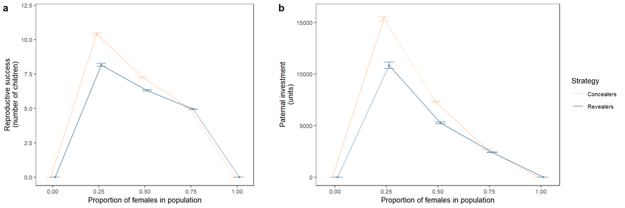

# 4. Proportion of Concealers (Concealer:Revealer ratio)

Next, we manipulate the proportion of Concealers among females.

```r
d <-
  read.csv('data/v6/cleanData/ovulationSensitivity2_ConcRevRatio.csv') %>%
  as_tibble() %>%
  mutate(Run       = factor(Run),
         Sens      = factor(Sens),
         Strategy  = factor(Strategy))
```

## 4.1. Analyses

We run mixed ANOVAs to determine (a) the main effect of Concealer:Revealer ratio, (b) the main effect of Strategy, and (c) the interaction between these. Our first ANOVA includes lifetime reproductive success as the dependent variable.

```r
m4.1 <- aov(RS ~ Sens*Strategy + Error(Run/Strategy), data = d)

summary(m4.1)
```

```
##
## Error: Run
##            Df Sum Sq Mean Sq F value Pr(>F)
## Sens        5   3288   657.7    2742 <2e-16 ***
## Residuals 594    142     0.2
## ---
## Signif. codes:  0 '***' 0.001 '**' 0.01 '*' 0.05 '.' 0.1 ' ' 1
##
## Error: Run:Strategy
##                Df Sum Sq Mean Sq F value Pr(>F)
## Strategy        1     75    74.9   785.6 <2e-16 ***
## Sens:Strategy   5   4941   988.3 10372.1 <2e-16 ***
## Residuals     594     57     0.1
## ---
## Signif. codes:  0 '***' 0.001 '**' 0.01 '*' 0.05 '.' 0.1 ' ' 1
```

```r
model.tables(m4.1, "means")
```

```
## Tables of means
## Grand mean
##
## 5.756624
##
##  Sens
## Sens
##     0   0.2   0.4   0.6   0.8     1
## 3.679 7.455 6.975 6.681 6.510 3.240
##
##  Strategy
## Strategy
## Concealers  Revealers
##      6.006      5.507
##
##  Sens:Strategy
##      Strategy
## Sens  Concealers Revealers
##   0   0.000      7.357
##   0.2 8.178      6.733
##   0.4 7.521      6.428
##   0.6 7.074      6.287
##   0.8 6.785      6.235
##   1   6.480      0.000
```

There’s a main effect of proportion of Concealers. The main effect of Strategy and interaction effect indicate that Concealers have more children than Revealers.

Let’s run the same model with paternal investment as the dependent variable.

```r
m4.2 <- aov(PI ~ Sens*Strategy + Error(Run/Strategy), data = d)

summary(m4.2)
```

```
##
## Error: Run
##            Df    Sum Sq   Mean Sq F value Pr(>F)
## Sens        5 3.343e+09 668690716   864.2 <2e-16 ***
## Residuals 594 4.596e+08    773806
## ---
## Signif. codes:  0 '***' 0.001 '**' 0.01 '*' 0.05 '.' 0.1 ' ' 1
##
## Error: Run:Strategy
##                Df    Sum Sq   Mean Sq F value Pr(>F)
## Strategy        1 3.870e+08 386957022   839.1 <2e-16 ***
## Sens:Strategy   5 4.970e+09 993911336  2155.4 <2e-16 ***
## Residuals     594 2.739e+08    461135
## ---
## Signif. codes:  0 '***' 0.001 '**' 0.01 '*' 0.05 '.' 0.1 ' ' 1
```

```r
model.tables(m4.2, "means")
```

```
## Tables of means
## Grand mean
##
## 5456.752
##
##  Sens
## Sens
##    0  0.2  0.4  0.6  0.8    1
## 3671 7680 6660 6089 5762 2879
##
##  Strategy
## Strategy
## Concealers  Revealers
##       6025       4889
##
##  Sens:Strategy
##      Strategy
## Sens  Concealers Revealers
##   0      0       7343
##   0.2 9280       6080
##   0.4 7855       5465
##   0.6 6939       5239
##   0.8 6318       5207
##   1   5757          0
```

We get the same pattern.

## 4.2. Visualisation

We now visualise the interaction between Concealer:Revealer ratio and female strategy with two line graphs, one for each dependent variable. Again, the code for this plot is hidden (see the source .Rmd code for details).

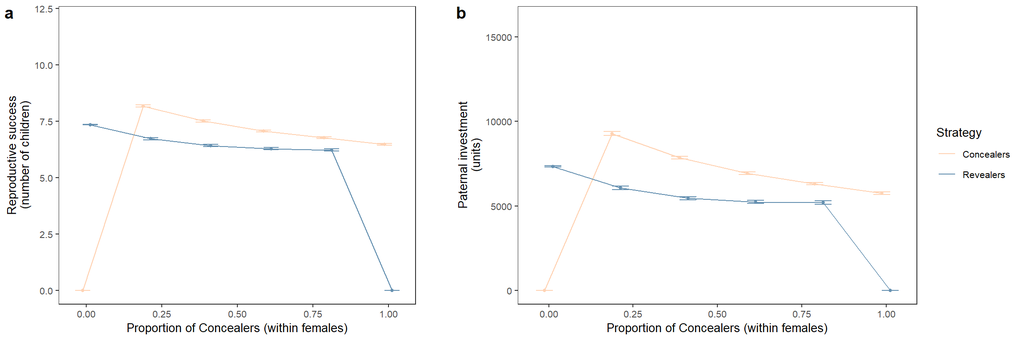

# 5. Lattice size

Next, we manipulate the size of the world. It’s always a square (height == width).

```r
d <-
  read.csv('data/v6/cleanData/ovulationSensitivity2_LatticeSize.csv') %>%
  as_tibble() %>%
  mutate(Run       = factor(Run),
         Sens      = factor(Sens),
         Strategy  = factor(Strategy))
```

There are 1000 rows (5 lattice sizes x 100 runs x 2 female strategies).

## 5.1. Analyses

We run mixed ANOVAs to determine (a) the main effect of lattice size, (b) the main effect of Strategy, and (c) the interaction between these. Our first ANOVA includes lifetime reproductive success as the dependent variable.

```r
m5.1 <- aov(RS ~ Sens*Strategy + Error(Run/Strategy), data = d)

summary(m5.1)
```

```
##
## Error: Run
##            Df Sum Sq Mean Sq F value Pr(>F)
## Sens        4  404.5  101.13   218.8 <2e-16 ***
## Residuals 495  228.8    0.46
## ---
## Signif. codes:  0 '***' 0.001 '**' 0.01 '*' 0.05 '.' 0.1 ' ' 1
##
## Error: Run:Strategy
##                Df Sum Sq Mean Sq F value Pr(>F)
## Strategy        1  348.2   348.2 4693.64 <2e-16 ***
## Sens:Strategy   4   18.4     4.6   62.01 <2e-16 ***
## Residuals     495   36.7     0.1
## ---
## Signif. codes:  0 '***' 0.001 '**' 0.01 '*' 0.05 '.' 0.1 ' ' 1
```

```r
model.tables(m5.1, "means")
```

```
## Tables of means
## Grand mean
##
## 6.21
##
##  Sens
## Sens
##    11    21    31    41    51
## 6.938 6.812 6.301 5.738 5.261
##
##  Strategy
## Strategy
## Concealers  Revealers
##       6.80       5.62
##
##  Sens:Strategy
##     Strategy
## Sens Concealers Revealers
##   11 7.428      6.448
##   21 7.265      6.358
##   31 6.821      5.781
##   41 6.408      5.068
##   51 6.079      4.443
```

There’s a main effect of world size. Presumably, this is because with larger worlds, agents have to spend more time and energy searching for mates. The main effect of Strategy and interaction effect indicate that Concealers have more children than Revealers.

Let’s run the same model with paternal investment as the dependent variable.

```r
m5.2 <- aov(PI ~ Sens*Strategy + Error(Run/Strategy), data = d)

summary(m5.2)
```

```
##
## Error: Run
##            Df    Sum Sq  Mean Sq F value   Pr(>F)
## Sens        4  50755576 12688894   11.52 5.95e-09 ***
## Residuals 495 545116937  1101246
## ---
## Signif. codes:  0 '***' 0.001 '**' 0.01 '*' 0.05 '.' 0.1 ' ' 1
##
## Error: Run:Strategy
##                Df    Sum Sq   Mean Sq F value   Pr(>F)
## Strategy        1 1.461e+09 1.461e+09 3184.98  < 2e-16 ***
## Sens:Strategy   4 3.719e+07 9.299e+06   20.27 1.77e-15 ***
## Residuals     495 2.271e+08 4.587e+05
## ---
## Signif. codes:  0 '***' 0.001 '**' 0.01 '*' 0.05 '.' 0.1 ' ' 1
```

```r
model.tables(m5.2, "means")
```

```
## Tables of means
## Grand mean
##
## 6080.66
##
##  Sens
## Sens
##   11   21   31   41   51
## 6084 6321 6290 6013 5696
##
##  Strategy
## Strategy
## Concealers  Revealers
##       7289       4872
##
##  Sens:Strategy
##     Strategy
## Sens Concealers Revealers
##   11 7580       4587
##   21 7290       5352
##   31 7332       5247
##   41 7205       4821
##   51 7039       4353
```

Same pattern.

## 5.2. Visualisation

We now visualise the interaction between lattice size and female strategy with two line graphs, one for each dependent variable. Again, the code for this plot is hidden (see the source .Rmd code for details).

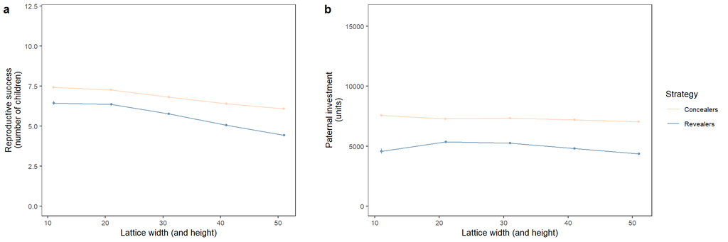

# 6. Aggression

Finally, we observe the targets of aggression. This isn’t a sensitivity analysis as such, just a check to see patterns of aggression over time within the model.

## 6.1. Experiment 2 conditions

We first look at aggression under conditions of Experiment 2 (aggression towards more attractive rivals).

```r
d <-
  read.csv('data/v6/cleanData/ovulationAggressTargets_Exp2.csv') %>%
  as_tibble() %>%
  mutate(run       = factor(run),
         target    = factor(target),
         strategy  = factor(strategy))
```

There are 602,439 acts of aggression across all 20 model runs.

Let’s see how many acts of aggression there are across model runs. Here, each point is a model run, and the y-axis measures total number of aggression acts.

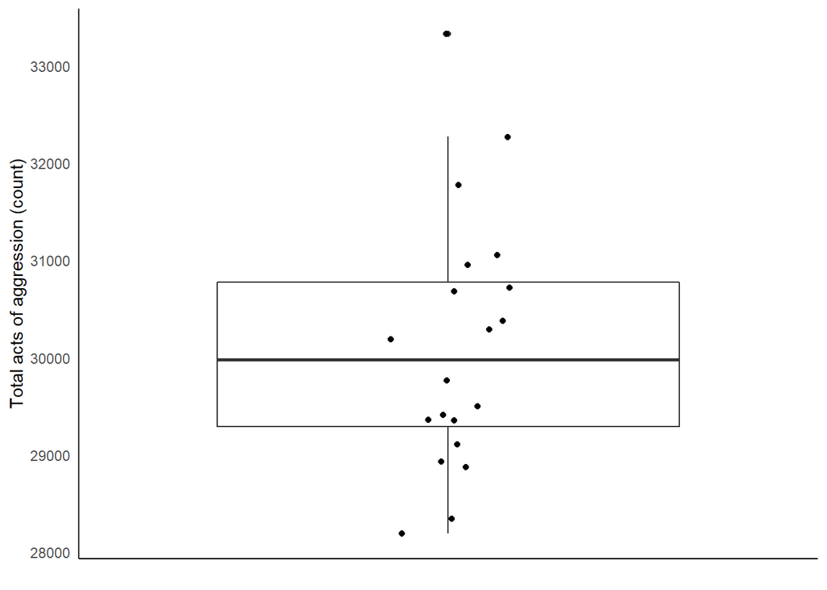

There’s some variation, but there are around 30,000 acts of aggression per model (on average).

What about over time?

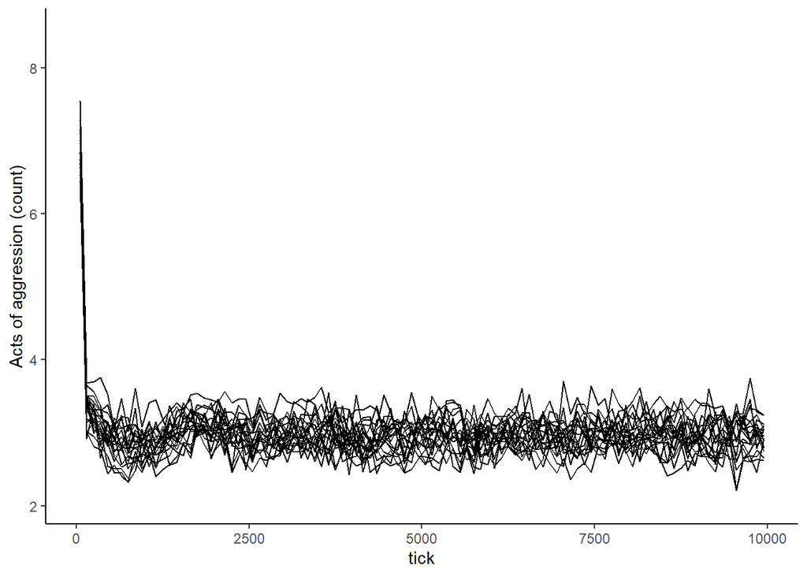

There are many acts of aggression at the beginning, likely because there is a larger spread of females across the lattice. But when females become pregnant and stay still, the amount of aggression plateaus.

Is there variation in the aggression each individual receives? Each individual is a point in the following plot, split by each independent model run and by the individual’s strategy.

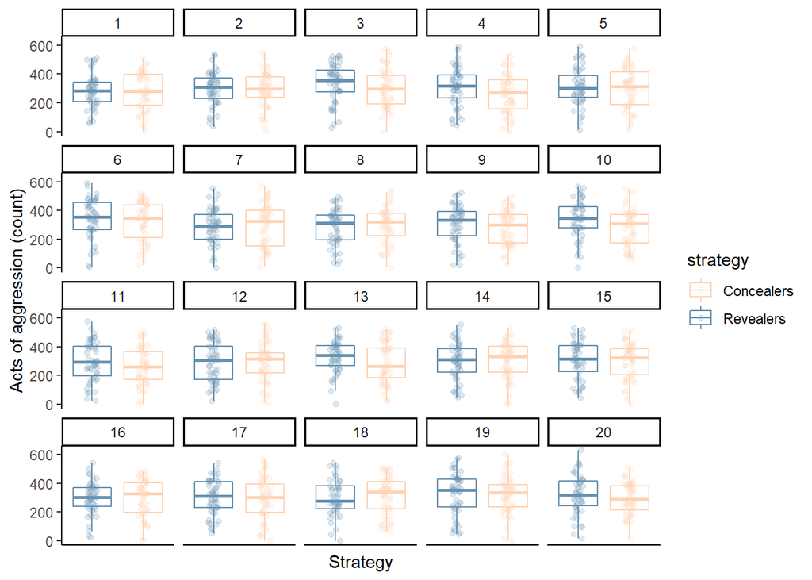

What’s the average number across simulations for Concealers?

```
## [1] 294.003
```

And the variation?

```
## [1] 130.9691
```

Agents receive around 294 acts of aggression on average, with standard deviation 130.

And for Revealers?

```
## [1] 308.436
```

```
## [1] 127.3397
```

Does the amount of aggression vary across strategies?

```r
summary(lmer(n ~ 1 + strategy + (1 | run), data = d_summarise))
```

```
## Linear mixed model fit by REML. t-tests use Satterthwaite's method [
## lmerModLmerTest]
## Formula: n ~ 1 + strategy + (1 | run)
##    Data: d_summarise
##
## REML criterion at convergence: 25108.9
##
## Scaled residuals:
##      Min       1Q   Median       3Q      Max
## -2.39127 -0.72568  0.08226  0.73413  2.48042
##
## Random effects:
##  Groups   Name        Variance  Std.Dev.
##  run      (Intercept)     7.017   2.649
##  Residual             16677.486 129.141
## Number of obs: 2000, groups:  run, 20
##
## Fixed effects:
##                   Estimate Std. Error       df t value Pr(>|t|)
## (Intercept)        294.003      4.127   72.323  71.247   <2e-16 ***
## strategyRevealers   14.433      5.775 1979.000   2.499   0.0125 *
## ---
## Signif. codes:  0 '***' 0.001 '**' 0.01 '*' 0.05 '.' 0.1 ' ' 1
##
## Correlation of Fixed Effects:
##             (Intr)
## strtgyRvlrs -0.700
```

Yes. Revealers receive 14 acts of aggression more (on average) than Concealers.

Save histogram to file.

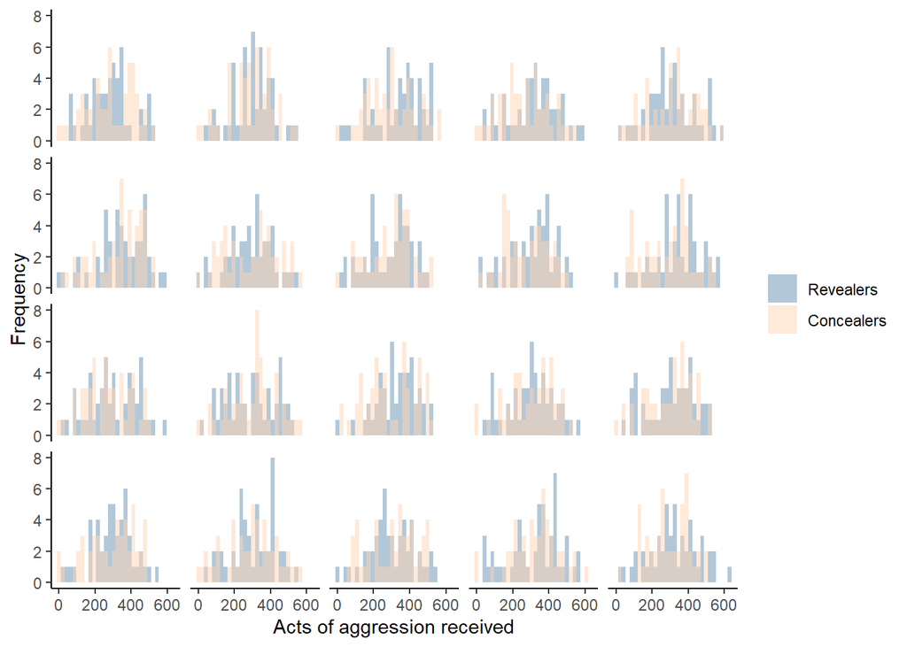

## 6.2. Experiment 3 conditions

We next look at aggression under conditions of Experiment 3 (aggression towards ovulating rivals).

```r
d <-
  read.csv('data/v6/cleanData/ovulationAggressTargets_Exp3.csv') %>%
  as_tibble() %>%
  mutate(run       = factor(run),
         target    = factor(target),
         strategy  = factor(strategy))
```

There are 941,075 acts of aggression across all 20 model runs.

Let’s see how many acts of aggression there are across model runs. Here, each point is a model run, and the y-axis measures total number of aggression acts.

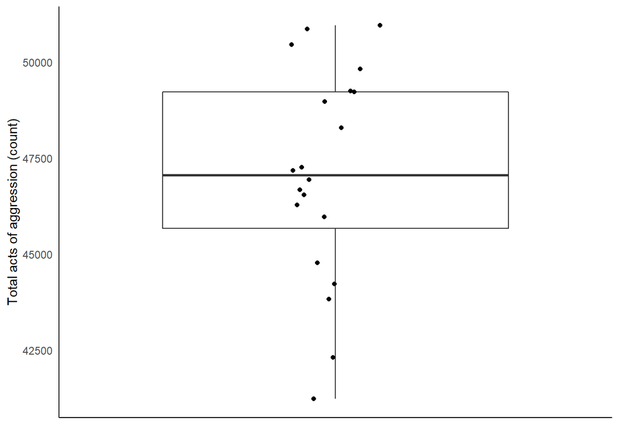

There’s some variation in the amount of aggression instantiated across different model runs, but on the whole there are around 47,500 agression acts per simulation. It seems that there’s more aggression in Experiment 3 compared to Experiment 2.

What about over time?

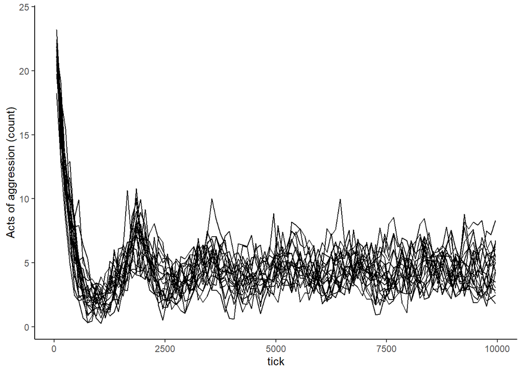

We find the same effect as in Experiment 2.

Is there variation in the amount of aggression each agent receives? Here, each point is an individual agent within a simulation.

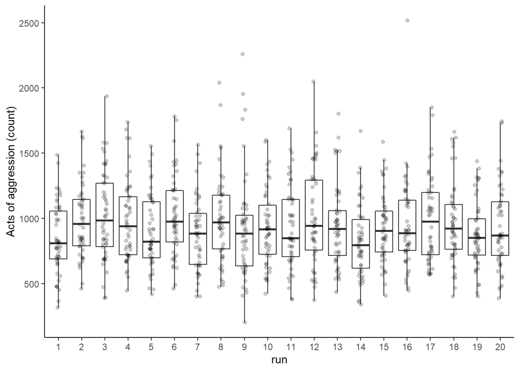

What’s the average number across simulations?

```
## [1] 941.075
```

And the variation?

```
## [1] 312.176
```

Agents receive around 941 acts of aggression on average, with standard deviation 312.

As a histogram:

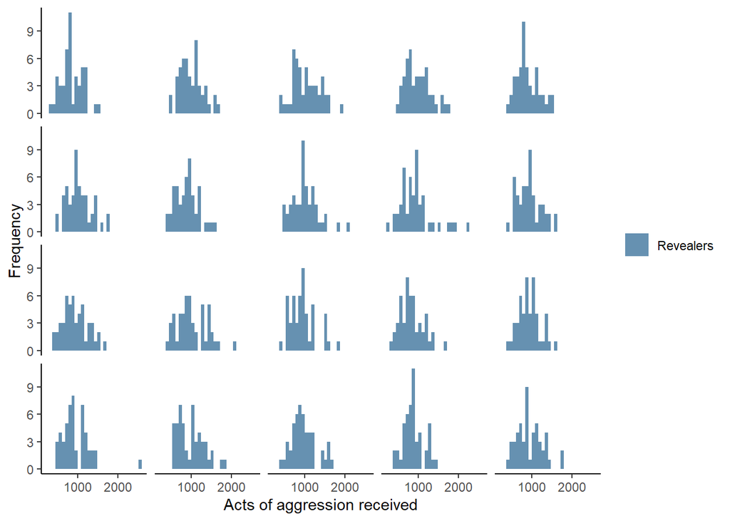